# Web Scraping

Asmik & Lisa – for Intro to NLP

April/May 2021

[figure not shown]

## Web Scraping from the IMDb Website

This demo is about basic **web scraping**.

We show how to parse (static) HTML content, extract relevant information, and store it in an R-friendly manner.

```r
# Load required packages

library(tidyverse)
library(rvest)
library(stringr)
library(xml2)
```

### Get contents

Specify URL for desired website to be scraped (http://www.imdb.com/chart/top?ref_=nv_mv_250_6) and parse website contents:

```r
(url <- xml2::read_html("http://www.imdb.com/chart/top?ref_=nv_mv_250_6"))
```

```
## {html_document}
## <html xmlns:og="http://ogp.me/ns#" xmlns:fb="http://www.facebook.com/2008/fbml">
## [1] <head>\n<meta http-equiv="Content-Type" content="text/html; charset=UTF-8 ...
## [2] <body id="styleguide-v2" class="fixed">\n            <img height="1" widt ...
```

### Explore contents

Website contents do not come in nice tabular form – we need to access them using HTML nodes / CSS selectors (actual content is written in HTML, whereas CSS is responsible for style elements).

HTML nodes can be found via the developer tab (F12) in Google Chrome or using helper tools like [SelectorGadget](https://selectorgadget.com/) (including video tutorial).

Let’s see what our IMDb website looks like using the developer tab. Chrome offers a feature that lets us hover over the website and display the corresponding source code section. We inspect the title element “Top Rated Movies”:

[figure not shown]

The title element is apparently of class `header`. We obtain the same result using SelectorGadget (see pane in bottom-right corner):

[figure not shown]

### Get movie titles

Using SelectorGadget once more, we find the movie titles to be stored in an element called `.titleColumn a` (note that SelectorGadget separates selectors by comma):

[figure not shown]

Once we have found this (which might take a while if the website structure is nested, so prepare for some trial-and-error here), `rvest` makes the rest rather convenient:

```r
title_data <- rvest::html_nodes(url, ".titleColumn a") %>%
  rvest::html_text()
```

```r
head(title_data)
```

```
## [1] "Die Verurteilten"       "Der Pate"               "Der Pate 2"
## [4] "The Dark Knight"        "Die zwölf Geschworenen" "Schindlers Liste"
```

### Get release years

In order to scrape the movies’ year of release, we check again for the corresponding selector, this time using the developer pane:

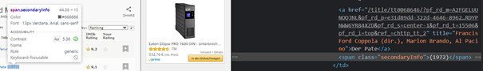

```r
year_data <- rvest::html_nodes(url, ".secondaryInfo") %>%
  rvest::html_text()
```

```r
head(year_data)
```

```
## [1] "(1994)" "(1972)" "(1974)" "(2008)" "(1957)" "(1993)"
```

Most of the time, we will need to clean the data after scraping. We extract the years without parentheses (more on regular expressions coming soon) and convert to numeric:

```r
(year_data_clean <- year_data %>%
  stringr::str_replace_all(pattern = "[\\(\\)]", replacement = "") %>%
  as.numeric())
```

```
##   [1] 1994 1972 1974 2008 1957 1993 2003 1994 1966 2001 1999 1994 2010 2002 1980
##  [16] 1999 1990 1975 1954 1995 1991 2002 1997 1946 1977 1998 2001 2014 1999 2019
##  [31] 1994 1962 1995 2002 1985 1991 1960 1936 1994 1998 1931 2000 1988 2014 2006
##  [46] 2011 2006 1942 1968 1954 1988 1979 1979 2000 1981 1940 2006 2012 1957 1950
##  [61] 2008 1980 2018 1957 2019 1964 2018 2003 1997 2020 2016 1984 2012 1986 2017
##  [76] 1981 2018 2019 1963 1999 1995 1995 1984 1955 2009 2009 1997 1983 1968 1992
##  [91] 1931 2007 1958 1941 2012 1985 2000 1952 1959 2004 1948 1952 1962 1921 1987
## [106] 2016 2020 1971 1927 1976 1944 1960 1973 2011 2019 2010 2001 2000 1983 2010
## [121] 1962 1965 2009 1989 1997 1995 1950 1961 1985 1988 1975 2018 2004 2005 1950
## [136] 1959 1992 1997 2004 2013 1963 1961 1995 1948 2006 2007 2001 2009 1980 1988
## [151] 1974 1998 1925 1954 2017 2010 2007 1957 1980 1982 1999 2019 2015 2005 1949
## [166] 1957 1982 1957 1996 1998 1993 2003 2011 1996 2005 2003 1939 2003 1953 1954
## [181] 1979 1926 2014 1978 1924 2008 2015 2014 1995 1966 2009 2013 1993 1939 2002
## [196] 2014 2016 1942 2018 1975 1998 2019 2013 1928 2010 2015 1953 1959 2004 1989
## [211] 1976 1978 2011 1986 2016 1967 1959 2017 1996 2009 1986 1995 1979 2015 2004
## [226] 1940 2013 2007 1966 2001 2012 2000 2016 1976 2000 2018 1984 2020 1934 1966
## [241] 2004 1955 2021 1987 1994 1982 1997 2020 1927 2018
```

### Get rankings

Now you know the selector drill, let’s proceed to the movies’ rankings. The rankings are stored within `.titleColumn` but the numbering does not have a separate selector.

```r
rank_data <- rvest::html_nodes(url, ".titleColumn") %>%
  rvest::html_text()
```

```r
head(rank_data)
```

```
## [1] "\n      1.\n      Die Verurteilten\n        (1994)\n    "
## [2] "\n      2.\n      Der Pate\n        (1972)\n    "
## [3] "\n      3.\n      Der Pate 2\n        (1974)\n    "
## [4] "\n      4.\n      The Dark Knight\n        (2008)\n    "
## [5] "\n      5.\n      Die zwölf Geschworenen\n        (1957)\n    "
## [6] "\n      6.\n      Schindlers Liste\n        (1993)\n    "
```

We clean the extracted ranking data and convert to numeric, by first removing unwanted characters and white spaces…

```r
rank_data_clean <- rank_data %>%
  stringr::str_replace_all(pattern = "\n", replacement = "") %>%
  stringr::str_squish()

head(rank_data_clean)
```

```
## [1] "1. Die Verurteilten (1994)"       "2. Der Pate (1972)"
## [3] "3. Der Pate 2 (1974)"             "4. The Dark Knight (2008)"
## [5] "5. Die zwölf Geschworenen (1957)" "6. Schindlers Liste (1993)"
```

… and then extracting, for each entry, the number before the dot:

```r
(rank_data_clean <- sapply(
  rank_data_clean,
  function(i) unlist(stringr::str_split(i, pattern = "\\."))[1]) %>%
  as.numeric())
```

```
##   [1]   1   2   3   4   5   6   7   8   9  10  11  12  13  14  15  16  17  18
##  [19]  19  20  21  22  23  24  25  26  27  28  29  30  31  32  33  34  35  36
##  [37]  37  38  39  40  41  42  43  44  45  46  47  48  49  50  51  52  53  54
##  [55]  55  56  57  58  59  60  61  62  63  64  65  66  67  68  69  70  71  72
##  [73]  73  74  75  76  77  78  79  80  81  82  83  84  85  86  87  88  89  90
##  [91]  91  92  93  94  95  96  97  98  99 100 101 102 103 104 105 106 107 108
## [109] 109 110 111 112 113 114 115 116 117 118 119 120 121 122 123 124 125 126
## [127] 127 128 129 130 131 132 133 134 135 136 137 138 139 140 141 142 143 144
## [145] 145 146 147 148 149 150 151 152 153 154 155 156 157 158 159 160 161 162
## [163] 163 164 165 166 167 168 169 170 171 172 173 174 175 176 177 178 179 180
## [181] 181 182 183 184 185 186 187 188 189 190 191 192 193 194 195 196 197 198
## [199] 199 200 201 202 203 204 205 206 207 208 209 210 211 212 213 214 215 216
## [217] 217 218 219 220 221 222 223 224 225 226 227 228 229 230 231 232 233 234
## [235] 235 236 237 238 239 240 241 242 243 244 245 246 247 248 249 250
```

### Get ratings

The ratings are easier to handle:

```r
rating_data <- rvest::html_nodes(url, "strong") %>%
  rvest::html_text()

head(rating_data)
```

```
## [1] "9.2" "9.1" "9.0" "9.0" "8.9" "8.9"
```

Convert ratings to numeric:

```r
(rating_data_clean <- rating_data %>%
  as.numeric())
```

```
##   [1] 9.2 9.1 9.0 9.0 8.9 8.9 8.9 8.8 8.8 8.8 8.8 8.7 8.7 8.7 8.7 8.6 8.6 8.6
##  [19] 8.6 8.6 8.6 8.6 8.6 8.6 8.6 8.5 8.5 8.5 8.5 8.5 8.5 8.5 8.5 8.5 8.5 8.5
##  [37] 8.5 8.5 8.5 8.5 8.5 8.5 8.5 8.5 8.5 8.5 8.5 8.4 8.4 8.4 8.4 8.4 8.4 8.4
##  [55] 8.4 8.4 8.4 8.4 8.4 8.4 8.4 8.4 8.4 8.4 8.4 8.4 8.4 8.3 8.3 8.3 8.3 8.3
##  [73] 8.3 8.3 8.3 8.3 8.3 8.3 8.3 8.3 8.3 8.3 8.3 8.3 8.3 8.3 8.3 8.3 8.3 8.3
##  [91] 8.3 8.3 8.3 8.3 8.3 8.3 8.3 8.3 8.3 8.3 8.3 8.3 8.2 8.2 8.2 8.2 8.2 8.2
## [109] 8.2 8.2 8.2 8.2 8.2 8.2 8.2 8.2 8.2 8.2 8.2 8.2 8.2 8.2 8.2 8.2 8.2 8.2
## [127] 8.2 8.2 8.2 8.2 8.2 8.2 8.2 8.2 8.2 8.2 8.2 8.2 8.2 8.2 8.2 8.2 8.2 8.2
## [145] 8.2 8.2 8.1 8.1 8.1 8.1 8.1 8.1 8.1 8.1 8.1 8.1 8.1 8.1 8.1 8.1 8.1 8.1
## [163] 8.1 8.1 8.1 8.1 8.1 8.1 8.1 8.1 8.1 8.1 8.1 8.1 8.1 8.1 8.1 8.1 8.1 8.1
## [181] 8.1 8.1 8.1 8.1 8.1 8.1 8.1 8.1 8.1 8.1 8.1 8.1 8.1 8.1 8.1 8.1 8.1 8.1
## [199] 8.1 8.1 8.1 8.1 8.1 8.1 8.1 8.1 8.1 8.1 8.1 8.1 8.1 8.1 8.1 8.1 8.1 8.1
## [217] 8.1 8.0 8.0 8.0 8.0 8.0 8.0 8.0 8.0 8.0 8.0 8.0 8.0 8.0 8.0 8.0 8.0 8.0
## [235] 8.0 8.0 8.0 8.0 8.0 8.0 8.0 8.0 8.0 8.0 8.0 8.0 8.0 8.0 8.0 8.0
```

### Store scraped data

Now we have everything we need and can store the data in an R-friendly object.

We will use a `data.frame` here. If you need to handle large data, you might want to consider using `data.table` instead, a powerful and very fast package for general data handling (its syntax is a bit different though).

```r
imdb_scraped_data <- data.frame(
  ranking = rank_data_clean,
  title = title_data,
  year = year_data_clean,
  rating = rating_data_clean)

head(imdb_scraped_data)
```

```
##   ranking                  title year rating
## 1       1       Die Verurteilten 1994    9.2
## 2       2               Der Pate 1972    9.1
## 3       3             Der Pate 2 1974    9.0
## 4       4        The Dark Knight 2008    9.0
## 5       5 Die zwölf Geschworenen 1957    8.9
## 6       6       Schindlers Liste 1993    8.9
```

**Nice, now we can use the movie data just like any other R object.**